# 452_Assignment_3

Shaolong (Fred) Xue

2023-01-27

```r
library(dplyr)
```

```r
library(ggplot2)
library(caret)
library(glmnet)
```

## Question 1 - Part 1

```r
hearts <- read.csv("heart.csv")

summary(hearts)
```

```
##    past_pain        density           age            weight
##  Min.   : 0.00   Min.   :0.995   Min.   :22.00   Min.   :118.5
##  1st Qu.:12.78   1st Qu.:1.043   1st Qu.:35.00   1st Qu.:159.0
##  Median :18.80   Median :1.056   Median :43.00   Median :175.8
##  Mean   :18.59   Mean   :1.056   Mean   :43.68   Mean   :178.3
##  3rd Qu.:24.00   3rd Qu.:1.071   3rd Qu.:51.00   3rd Qu.:195.8
##  Max.   :45.10   Max.   :1.109   Max.   :81.00   Max.   :363.1
##
##      height       fat_free_wt    family_record     neck_dim
##  Min.   :29.50   Min.   :107.9   Mode:logical   Min.   :31.10
##  1st Qu.:68.38   1st Qu.:131.1   NA's:240       1st Qu.:36.40
##  Median :70.25   Median :141.3                  Median :37.90
##  Mean   :70.21   Mean   :143.7                  Mean   :37.94
##  3rd Qu.:72.25   3rd Qu.:153.9                  3rd Qu.:39.40
##  Max.   :77.75   Max.   :240.5                  Max.   :51.20
##  NA's   :1       NA's   :1
##    chest_dim        abdom_dim      past_record       hip_dim
##  Min.   : 79.30   Min.   : 69.40   Mode:logical   Min.   : 85.0
##  1st Qu.: 94.15   1st Qu.: 84.58   NA's:240       1st Qu.: 95.6
##  Median : 99.60   Median : 90.80                  Median : 99.3
##  Mean   :100.46   Mean   : 92.07                  Mean   : 99.9
##  3rd Qu.:104.95   3rd Qu.: 98.65                  3rd Qu.:103.1
##  Max.   :136.20   Max.   :148.10                  Max.   :147.7
##  NA's   :4                                        NA's   :2
##    thigh_dim        knee_dim       wrist_dim       ankle_dim
##  Min.   :47.20   Min.   :33.00   Min.   :10.40   Min.   :19.10
##  1st Qu.:56.05   1st Qu.:36.90   1st Qu.:10.57   1st Qu.:22.00
##  Median :58.90   Median :38.40   Median :10.75   Median :22.80
##  Mean   :59.44   Mean   :38.52   Mean   :10.75   Mean   :23.11
##  3rd Qu.:62.30   3rd Qu.:39.80   3rd Qu.:10.93   3rd Qu.:24.00
##  Max.   :87.30   Max.   :49.10   Max.   :11.10   Max.   :33.90
##  NA's   :1                       NA's   :238
##    biceps_dim     forearm_dim     wrist_dim.1     heart_attack
##  Min.   :24.80   Min.   :21.00   Min.   :15.80   Min.   :18.10
##  1st Qu.:30.20   1st Qu.:27.30   1st Qu.:17.60   1st Qu.:23.10
##  Median :32.00   Median :28.70   Median :18.20   Median :24.85
##  Mean   :32.25   Mean   :28.66   Mean   :18.19   Mean   :25.30
##  3rd Qu.:34.10   3rd Qu.:30.00   3rd Qu.:18.80   3rd Qu.:27.05
##  Max.   :45.00   Max.   :34.90   Max.   :21.40   Max.   :48.90
##  NA's   :1
```

#### Choosing Sample Subset

From the summary of the data, a few columns are full or almost full of missing values. I will simply remove these columns: “family_record”, “past_record”, and “wrist_dim”. Additionally, several columns also contain just a few missing values, ranging from 1 to 4. I will simply remove the rows with missing values for these columns. The collatoral removal of information will not make that much of a difference to the integrity of the dataset. After these two adjustments, the remaining will be my chosen sample subset.

#### Choosing Train/Fit Subset

```r
## removing all missing values
hearts_nona <- hearts %>%
  select(-family_record, -past_record, -wrist_dim) %>%
  na.omit
```

## Question 1 - Part 2

#### Train/Test Split

```r
set.seed(1)

## adding id variable
hearts_nona$id <- 1:nrow(hearts_nona)

## 75% train; 25% test
train <- hearts_nona %>% sample_frac(0.75)
test <- dplyr::anti_join(hearts_nona, train, by = 'id')

## removing id variable
train <- train %>% select(-id)
test <- test %>% select(-id)

dim(train)
```

```
## [1] 172  17
```

```r
dim(test)
```

```
## [1] 58 17
```

#### Some EDA

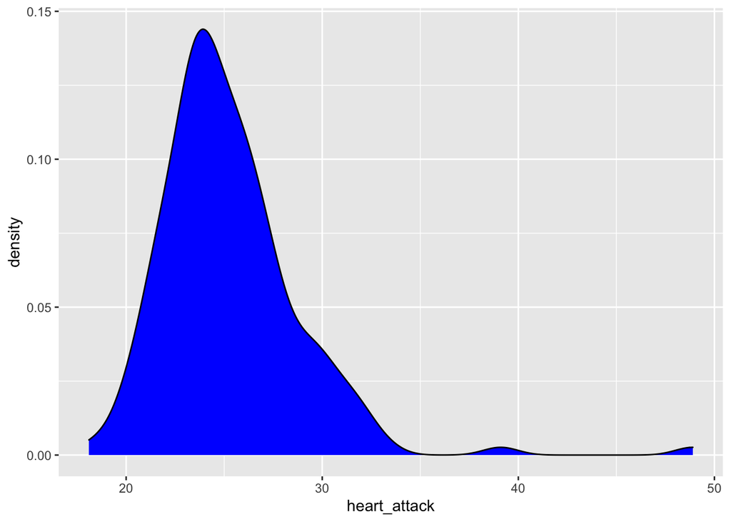

```r
## original
ggplot(train, aes(heart_attack)) +
  geom_density(fill = "blue")
```

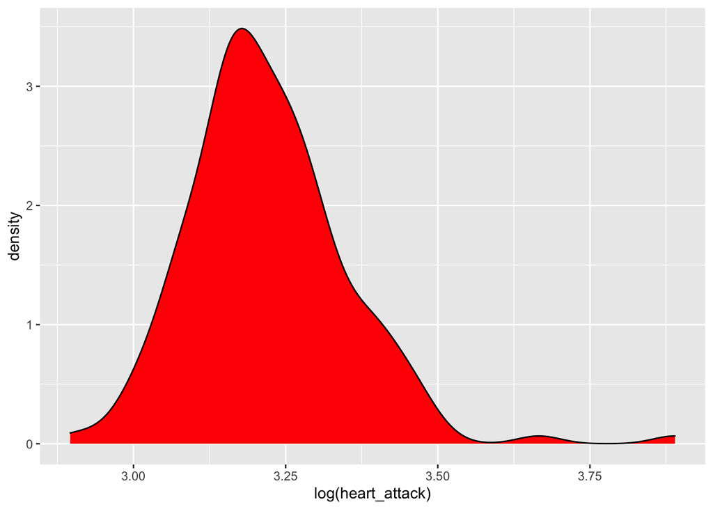

```r
## log transformed y
ggplot(train, aes(log(heart_attack))) +
  geom_density(fill = "red")
```

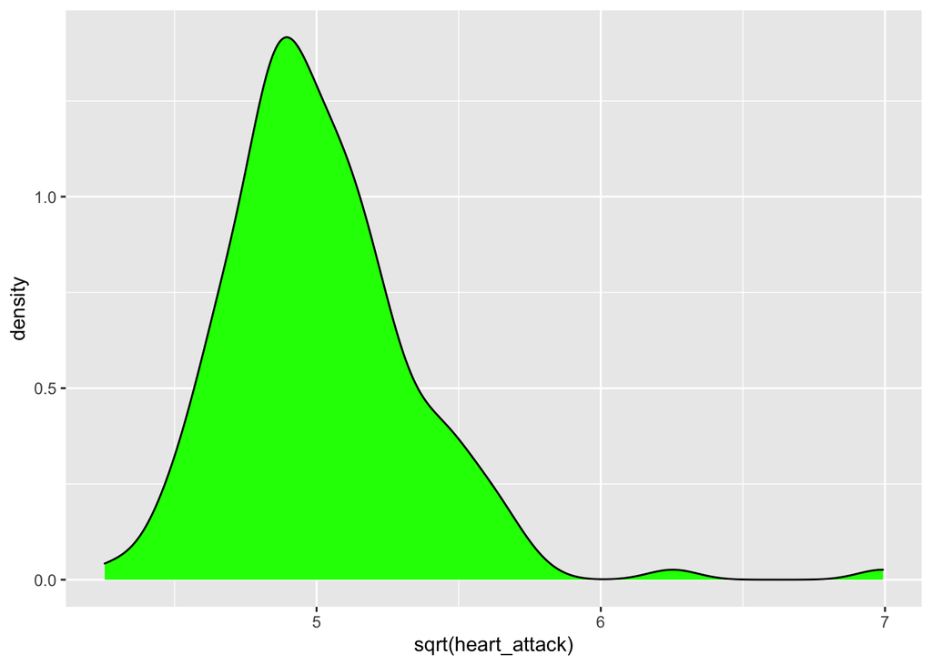

```r
## sqrt transformed y
ggplot(train, aes(sqrt(heart_attack))) +
  geom_density(fill = "green")
```

Log seems to be transforming the response variable the closest to normal.

#### SLR

```r
## the full model
model1 <- lm(log(heart_attack) ~ ., data = train)
summary(model1)
```

```
##
## Call:
## lm(formula = log(heart_attack) ~ ., data = train)
##
## Residuals:
##      Min       1Q   Median       3Q      Max
## -0.14361 -0.01844  0.00178  0.02340  0.06703
##
## Coefficients:
##               Estimate Std. Error t value Pr(>|t|)
## (Intercept)  3.436e+00  9.340e-01   3.679 0.000323 ***
## past_pain   -2.451e-03  2.696e-03  -0.909 0.364636
## density     -1.324e+00  8.394e-01  -1.578 0.116677
## age         -1.582e-04  3.290e-04  -0.481 0.631365
## weight      -3.648e-05  7.698e-04  -0.047 0.962264
## height      -4.869e-03  8.004e-04  -6.083 8.85e-09 ***
## fat_free_wt  9.155e-06  9.572e-04   0.010 0.992381
## neck_dim     7.523e-03  2.307e-03   3.262 0.001362 **
## chest_dim    6.684e-03  9.113e-04   7.334 1.17e-11 ***
## abdom_dim    2.358e-03  1.019e-03   2.313 0.022025 *
## hip_dim      5.297e-04  1.354e-03   0.391 0.696300
## thigh_dim    5.939e-03  1.542e-03   3.851 0.000172 ***
## knee_dim    -3.853e-03  2.457e-03  -1.569 0.118775
## ankle_dim   -1.224e-04  2.280e-03  -0.054 0.957264
## biceps_dim   1.473e-03  1.569e-03   0.939 0.349163
## forearm_dim  1.240e-03  1.692e-03   0.733 0.464605
## wrist_dim.1  3.939e-03  5.160e-03   0.763 0.446404
## ---
## Signif. codes:  0 '***' 0.001 '**' 0.01 '*' 0.05 '.' 0.1 ' ' 1
##
## Residual standard error: 0.03275 on 155 degrees of freedom
## Multiple R-squared:  0.9427, Adjusted R-squared:  0.9368
## F-statistic: 159.5 on 16 and 155 DF,  p-value: < 2.2e-16
```

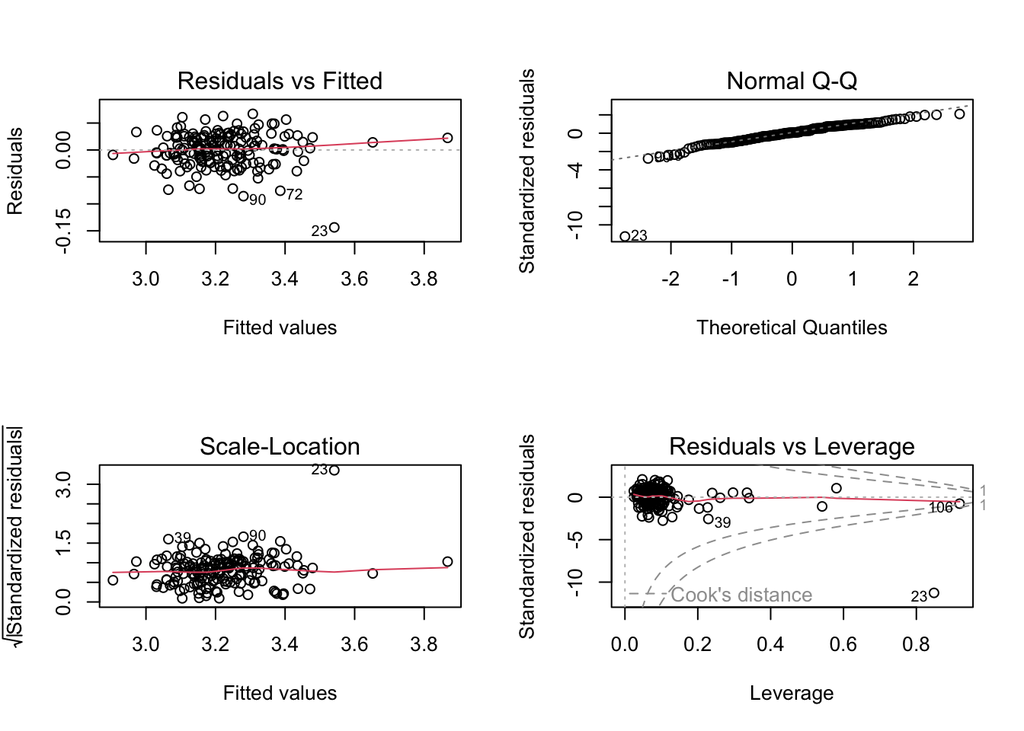

```r
## plotting the full model
par(mfrow = c(2,2))
plot(model1)
```

**Some quick observations**

All predictors have a clear collective effect on the response, heart attack. Global F is 159.5

Among them, height and dimensions of height, neck, chest, abdomen, and thigh are significant.

The full model has a pretty good fit. Adjusted $R^2$ is 0.9368.

#### Prediction and Test Set

```r
## prediction
pred1 <- predict(model1, newdata = test)

# calculating rsme
RMSE <- sqrt(sum((exp(pred1) - test$heart_attack)^2) / length(test$heart_attack))

# calculating out-of-sample R^2
os_sst <- sum((test$heart_attack - mean(train$heart_attack))^2)
os_ssr <- sum((test$heart_attack - exp(pred1))^2)
out_sample_R2 <- 1 - os_ssr / os_sst

## R2(pred1, test$heart_attack)

# storing in-sample R^2
in_sample_R2 <- summary(model1)$r.squared

result <- data.frame(in_sample_R2, out_sample_R2, RMSE)
result
```

```
##   in_sample_R2 out_sample_R2     RMSE
## 1    0.9427347     0.9030779 1.120699
```

**Summary**

The out-of-sample $R^2$ is 0.9. It is smaller than the in-sample $R^2$, which is 0.94. The RMSE is 1.12. It estimates on average how much of the predicted value will be from the actual value. In this case, 1.12 is pretty close.

## Question 2 - Cross Validation

Overall, cross validation (CV) is a technique that evaluates the performance of a ML model. It divides the data into folds (e.g. 10), and then train and test the model on different combinations of the folds of data. Model performance is averaged from each fold, giving a better assessment.

CV has a few problems. It can be time consuming and technically expensive to run; it may overfit the model; it can lead to a biased estimate if the folds are not created randomly.

## Question 3 - 8-fold CV

```r
## set up for train() function
train_control <- trainControl(method = "cv", number = 8)

## training the model with CV
model2 <- train(log(heart_attack) ~ ., data = train,
                method = "lm",
                trControl = train_control)

print(model2)
```

```
## Linear Regression
##
## 172 samples
##  16 predictor
##
## No pre-processing
## Resampling: Cross-Validated (8 fold)
## Summary of sample sizes: 149, 151, 150, 151, 150, 151, ...
## Resampling results:
##
##   RMSE        Rsquared   MAE
##   0.05641459  0.8658438  0.03106397
##
## Tuning parameter 'intercept' was held constant at a value of TRUE
```

**Comparison**

The mean $R^2$ of the 8-fold CV on the full model is about 0.87. This is **lower** than the out-of-sample $R^2$ I calculated earlier (0.903) without CV.

This was a bit surprising to me, as I thought CV should return a “better” result than regressing regularly. Then I thought of two possible reasons why the CV approach is yielding a lower $R^2$ value.

1. The data we’re using for CV is only the training set. The out-of-sample $R^2$ we calculated was based on predictions using the test data set. CV so far has never seen the test set. That’s probably why there’s difference.
2. The high $R^2$ value from Question 1 is not necessarily a good thing. It could mean that the model is over-fitting the data by including all of the variables. Although the CV technique is also applied on the full model, it nonetheless brings down the scale of over-fitting as shown by a lower $R^2$ value.

## Question 4 - Lasso Regression

Lasso regression is a technique in linear regression that minimizes the coefficients of unimportant variables to zero, using a regularization term. Lasso regression tries to minimize deviance, which now includes the SSR plus a penalty function. The penalty is the sum of absolute values of the betas multiplied by a constant lambda.

Essentially, if the benefit of including a variable outweighs the cost, then it’s included. Otherwise, the variable is excluded from the model. The lambda is the weight of the cost. The procedure starts with a large lambda (high cost factor) so no variable is included, goes over a sequence of decreasing lambda (lowering the cost factor; including more variables), and ends at a cut-off point (we don’t want the cost to be so low that we include more variables than we need; over-fitting).

The benefits of Lasso regression are obviously its function to feature the best variables that directly impact the response variable. And its ability to deal with a large number of x variables.

The cons of Lass regression include the fact that it is sensitive to scale and it doesn’t deal with multicollinearity very well (a variable that strongly impact the response indirectly can be excluded).

## Question 5 - Part 1: CV Lasso

```r
## setting up response and predictors
y <- train$heart_attack
x <- data.matrix(train)[, -c(17)]

model3 <- cv.glmnet(x, log(y))

## storing the minimum and 1se lambda values
lambda_min <- model3$lambda.min
lambda_1se <- model3$lambda.1se

data.frame(lambda_min, lambda_1se)
```

```
##   lambda_min lambda_1se
## 1 0.01066577 0.01409952
```

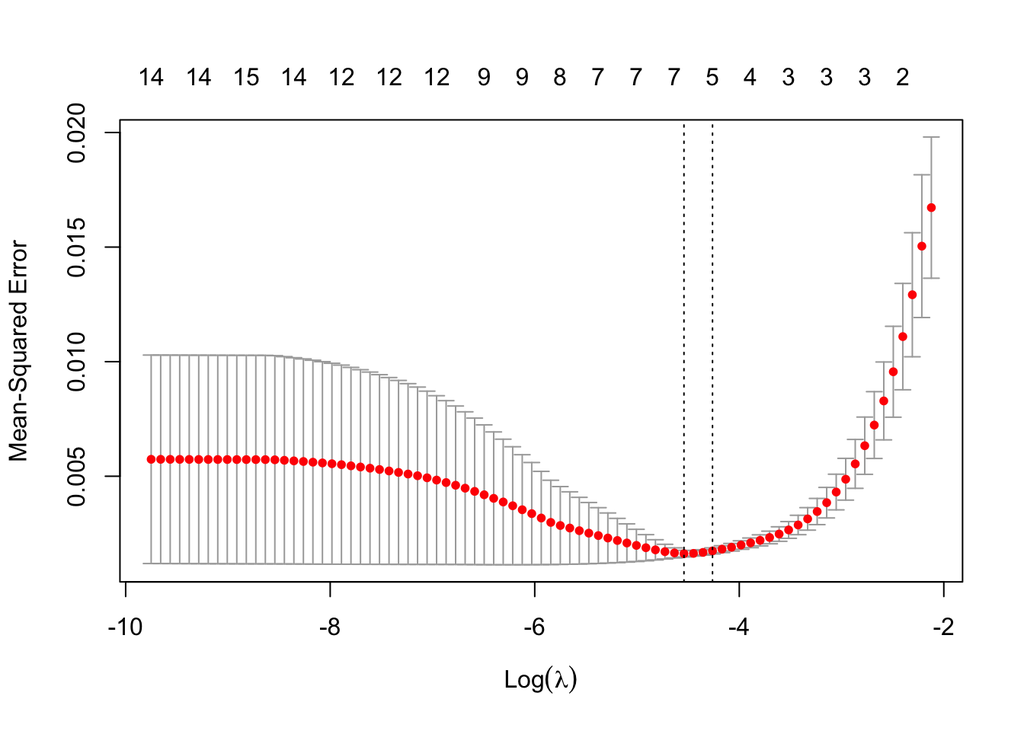

```r
plot(model3)
```

```r
## running the CV Lasso models
model4_min <- glmnet(x, log(y), alpha = 1, lambda = lambda_min)
model5_1se <- glmnet(x, log(y), alpha = 1, lambda = lambda_1se)

## showing the selected variables within each model
coef(model4_min)
```

```
## 17 x 1 sparse Matrix of class "dgCMatrix"
##                        s0
## (Intercept)  2.0667805873
## past_pain    .
## density     -0.0949081606
## age          .
## weight       .
## height      -0.0015283541
## fat_free_wt  .
## neck_dim     0.0038147708
## chest_dim    0.0063189621
## abdom_dim    0.0027889435
## hip_dim      .
## thigh_dim    0.0052394502
## knee_dim     .
## ankle_dim    .
## biceps_dim   0.0004324417
## forearm_dim  .
## wrist_dim.1  .
```

```r
coef(model5_1se)
```

```
## 17 x 1 sparse Matrix of class "dgCMatrix"
##                        s0
## (Intercept)  1.9557722919
## past_pain    .
## density      .
## age          .
## weight       .
## height      -0.0004146585
## fat_free_wt  .
## neck_dim     0.0023576901
## chest_dim    0.0062051916
## abdom_dim    0.0030436685
## hip_dim      .
## thigh_dim    0.0050673473
## knee_dim     .
## ankle_dim    .
## biceps_dim   .
## forearm_dim  .
## wrist_dim.1  .
```

```r
## predicting with model 4 (lambda_min) and model 5 (lambda_1se) on train data
pred4 <- predict(model4_min, s = lambda_min, newx = x)
pred5 <- predict(model5_1se, s = lambda_1se, newx = x)

## R^2 for model 4
sst_m4 <- sum((y-mean(y))^2)
sse_m4 <- sum((exp(pred4) - y)^2)
R2_m4 <- 1 - sse_m4 / sst_m4

## R^2 for model 5
sst_m5 <- sum((y-mean(y))^2)
sse_m5 <- sum((exp(pred5) - y)^2)
R2_m5 <- 1 - sse_m5 / sst_m5
```

#### Asssessment

**Model 4**:

The model selected with minimum lambda contains 7 variables plus the intercept.

## Question 5 - Part 2: Overall Comparison

```r
## Question 1 R^2
lm_OOS_Rsquare <- out_sample_R2

## Question 3 R^2
CV_8fold_Rsquare <- model2$results$Rsquared

## Question 5 R^2
Lasso_min_Rsquare <- R2_m4
Lasso_1se_Rsquare <- R2_m5

data.frame(lm_OOS_Rsquare, CV_8fold_Rsquare, Lasso_min_Rsquare, Lasso_1se_Rsquare)
```

```
##   lm_OOS_Rsquare CV_8fold_Rsquare Lasso_min_Rsquare Lasso_1se_Rsquare
## 1      0.9030779        0.8658438          0.925085         0.9090923
```

The Lasso regression selected with minimum lambda yields the highest $R^2$ value.

The OOS $R^2$ from the simple linear regression is comparable with the $R^2$ value from the Lasso selected with 1se lambda.

The $R^2$ value from 8-fold CV on training data is the lowest.

## Question 6

Akaike Information Criterion (AIC) is a quality measure of model performance. AIC is the negative log-likelihood of the model plus a penalty term for the number of parameters (k) included. The lower the AIC, the better the model.

A drawback of AIC is that it tends to overfit in high dimensions. AIC-corrected (AICc) addresses this drawback by taking sample size into account. It does better with small sample sizes. Since AICc includes $k^2$, AIC is a first-order estimate while AICc is a second-order estimate.

For big n/df, AICc is similar to AIC. And as n approaches infinity, AICc converges to AIC. So, in practice, we should always use AICc as it covers the sample size issue that AIC lacks.